# Data Augmentation - AstroBin Title Skew

```python
# THIS is the template which all subsequent scaled iterations (1.1, 1.2, 1.3) were based on

import pandas as pd
import re
import warnings
from itertools import combinations
from nltk import bigrams  # Make sure to install the nltk library: pip install nltk
import classes_and_methods.soam_class as soam #contains a text cleaning method
import classes_and_methods.title_data_augmenter_class as augment
from collections import Counter
import random
import seaborn as sns
import matplotlib.pyplot as plt

from sklearn.model_selection import train_test_split
from sklearn.feature_extraction.text import TfidfVectorizer
from sklearn.metrics import f1_score
from sklearn.naive_bayes import MultinomialNB
from sklearn.linear_model import LogisticRegression
from sklearn.svm import LinearSVC
from sklearn.ensemble import RandomForestClassifier
from sklearn.metrics import classification_report, accuracy_score, mean_squared_error
from sklearn.pipeline import make_pipeline


help(augment.title_data_augmenter)
```

```
1068 lines from "Augement_Equipment_OPT" file downloaded for supplement
"Augement_NOCTILUCENT_CLOUDS_Wiki" string downloaded for supplement
89 lines from "Augement_NOCTILUCENT_CLOUDS_GPT" file downloaded for supplement
73 lines from "Augement_NORTHERN_LIGHTS_GPT" file downloaded for supplement
Help on function title_data_augmenter in module classes_and_methods.title_data_augmenter_class:

title_data_augmenter(df, counts_table, smoothing_factor, supplement_params, verbose=False)
    Where:
        df holds the un-augmented source data
        counts_table has a 'Subject' col that matches 'subject_types' in df col
        counts_table has a 'Count' col that holds the aggregated count of each corresponding 'Subject'
        smoothing factor is a float 0-1 (0 is no smoothing)
        supplement_params is a dict with 'subject_types' keys holding settings and data for:
            ['supplement_list'] #... this is a list or False
            ['supplement_str'] #... this is a string or False
            ['supplement_synonyms'] #... this is True or False
        verbose is not implemented at this time...
```

```python
#Helper Methods
def category_counts(df, cat_col, print_it = True):
    """
    Provided a data frame, df, and a category column name, cat_col...
        Print a table showing the categories and their corresponding:
            -Category name
            -Category record count
            -Percentage across all categories
    """
    # Get the value counts and create a DataFrame
    table = pd.DataFrame(df[cat_col].value_counts()).reset_index()
    # Rename the columns for clarity
    table.columns = ['Subject', 'Count']
    #set percentages column
    total = sum(table['Count'])
    table['Percentages'] = table['Count']/total
    if(print_it):
        # Display the table
        print("Table of subject_type Counts:")
        print(table)
        print(f'TOTAL = {total}')

    return table

def two_category_histogram(category1, category2, df, print_it = False):
    """
    Where:
        - category1 counts will be represented as a single bar
        - category2 counts within category1 will be represented by
            color on the corresponding category1 bar
        - df is a data frame with category1 and category2 two columns
    """
    # Create a cross-tabulation (count) of Category1 and Category2
    cross_tab = pd.crosstab(df[category1], df[category2])

    # Sort the DataFrame based on the counts of Category1 in descending order
    sorted_cross_tab = cross_tab.sum(axis=1).sort_values(ascending=False)
    cross_tab_sorted = cross_tab.loc[sorted_cross_tab.index]

    # Plot the histogram-like graph
    ax = cross_tab_sorted.plot(kind='bar', stacked=True, colormap='viridis', edgecolor='black')

    # Set the y-axis limit to be 20% greater than the second largest subject type
    y_limit = 1.2 * sorted_cross_tab.iloc[1]
    plt.ylim(0, y_limit)

    # Annotate bars that exceed the y-axis limit
    for i, (idx, row) in enumerate(cross_tab_sorted.iterrows()):
        if row.sum() > y_limit:
            ax.annotate(f'** / / **', xy=(i, y_limit), ha='center', va='bottom', color='red')

    # Customize the plot
    ax.set_xlabel(category1.upper())
    ax.set_ylabel('Count')
    ax.legend(title = category2.upper(), bbox_to_anchor=(1, 1))
    ax.tick_params(axis='x')
    ax.tick_params(axis='y')

    # Tilt x-axis tick labels at a 45-degree angle
    ax.set_xticklabels(ax.get_xticklabels(), rotation=35, ha='right')

    if print_it == True:
        # Show the plot
        print("PLOTTING CATEGORIES")
        plt.show()

    return(plt)
```

### Original Data

```python
# Data Load (provided by Salvatore from AstroBin site)
df = pd.read_csv("data/astrobin_titles_to_subject_types.csv") #the main starting data frame
#set data types
df['subject_type'] = df['subject_type'].astype('category') #subject_type is our pre-defined categories
df['title'] = df['title'].astype(str) #title is our text data
#data set cleaning
df = df.dropna(how='all') #droping only the rows with 'na' across ALL columns
df = df.dropna(subset=['title']) #droping only the rows with 'na' ONLY in title column
df = df[df['title'] != 'nan'] #droping only the rows with 'nan' ONLY in title column
df = df[~df['title'].str.isspace()] #droping only the rows with just '  ' (white space) as title
df = df[df['title']!=''] #droping only the rows with just '' (dead space) as title
df = df.dropna(subset=['subject_type']) #droping only the rows with 'na' subject_type
#cleaning out the odd '600' category, converting it to 'OTHER' (per email "Image Title Classification | AstroBin")
df['subject_type'] = df['subject_type'].replace('600','OTHER')
#title cleaning (text cleaning method can be reviewed in the appendix, referenced in imports)
df['cleaned_title'] = df['title'].apply(soam.provided_cleaning_method)

#Review the Original df
original_counts = category_counts(df,'subject_type')
```

```
Table of subject_type Counts:
              Subject   Count  Percentages
0            DEEP_SKY  444255     0.751298
1        SOLAR_SYSTEM  111233     0.188111
2          WIDE_FIELD   20108     0.034005
3               OTHER    9670     0.016353
4                GEAR    3587     0.006066
5         STAR_TRAILS    1628     0.002753
6     NORTHERN_LIGHTS     674     0.001140
7  NOCTILUCENT_CLOUDS     162     0.000274
TOTAL = 591317
```

```python
#Exploring title data augmentations
smoothing_factor = 0.9
df_augmented = augment.title_data_augmenter(df, original_counts, smoothing_factor,augment.supplement_params)
category_counts(df_augmented,'subject_type', print_it = False)
```

|  | Subject | Count | Percentages |
| --- | --- | --- | --- |
| 0 | DEEP_SKY | 110949 | 0.187631 |
| 1 | SOLAR_SYSTEM | 77646 | 0.131311 |
| 2 | WIDE_FIELD | 68534 | 0.115901 |
| 3 | OTHER | 67490 | 0.114136 |
| 4 | GEAR | 66881 | 0.113106 |
| 5 | STAR_TRAILS | 66686 | 0.112776 |
| 6 | NORTHERN_LIGHTS | 66590 | 0.112614 |
| 7 | NOCTILUCENT_CLOUDS | 66538 | 0.112526 |

## OPTIMIZATION SEARCH

```python
#Optimization parameters
optimize_params = {
    "gram_types":['char','word'], #must be 'word', 'char', or both
    "ngram_options": [1,2], #must be sorted in order [1,2,3]
    "smoothing_factor_steps":[round(x*0.1, 1) for x in range(0, 10 +1)], # in range --> 0 = 0.0, 5 = 0.5, 10 = 1.0
    #"smoothing_factor_steps":[round((x)*0.02+0.2, 2) for x in range(0, 30 +1)], #for fine tuning if needed...
    "model_choices":[
        MultinomialNB(),
        RandomForestClassifier(),
        LinearSVC(),
        LogisticRegression(solver='liblinear', multi_class='ovr')
    ]
}
```

```python
def optimize_classifier(df, optimize_params, sample_size = -1):
    """
    Where:
        -- sample size is the number of sampled rows to take from the passed df.
        -- optimize_params is a dict containing a list of all options
            where the listed options each contain the following choices:
            - "gram_types":['char','word'], #must be 'word', 'char', or both
            - "ngram_options": [1,2], #must be sorted in order [1,2,3]
            - "smoothing_factor_steps":[round(x*0.1, 1) for x in range(0, 10 +1)], # in range --> 0 = 0.0, 5 = 0.5, 10 = 1.0
            - #"smoothing_factor_steps":[round((x)*0.02+0.2, 2) for x in range(0, 30 +1)], #for fine tuning if needed...
            - "model_choices":[ #example model choices ...
                MultinomialNB(),
                RandomForestClassifier(),
                LinearSVC(),
                LogisticRegression(solver='liblinear', multi_class='ovr')
            ]
    """
    # HELPER Function to extract bigrams from a text
    def extract_bigrams(text):
        tokens = text.split()
        return list(bigrams(tokens))

    #collection bins........
    subject_type_counts = []
    model_names = []
    models = []
    reports = []
    accuracies = []

    data = {}
    #.......................

    #make df based on provided sample size
    df_sampled = None #default instantiated
    if sample_size>0:
        df_sampled = df.sample(n=sample_size)
    else:
        df_sampled = df
    original_counts = category_counts(df_sampled,'subject_type', print_it = False)

    #UNPACK smoothing_factor PARAMETERS:
    for smoothing_factor in optimize_params["smoothing_factor_steps"]:

        name = f"smooth_factor {smoothing_factor}"
        print("Working on smoothing data with",name) #TRACER
        #1. AUGMENT THE DATA --------------------------------------
        #augment the df according to smoothing factor...
        df_augmented = augment.title_data_augmenter(
            df_sampled, original_counts, smoothing_factor, augment.supplement_params)
        # ---------------------------------------------------------

        # RUN Model ----------------------------------------------------
        # Step 1: Load and Preprocess Data
        train_data, test_data, train_labels, test_labels = train_test_split(
            df_augmented['title'], df_augmented['subject_type'], test_size=0.2, random_state=333)

        # Step 2: Feature Extraction

        #UNPACK ngram PARAMETERS:
        # -- options [1,2] provide ranges [(1, 1), (1, 2), (2, 2)]
        ngram_ranges = [(x,y) for y in optimize_params["ngram_options"]
                         for x in optimize_params["ngram_options"] if y>=x]

        #with given params, build vectorizer options
        vectorizer_options = []
        for gram in optimize_params["gram_types"]:
            for ngram_range in ngram_ranges:
                if gram == 'char':
                    vectorizer_options.append(
                        TfidfVectorizer(ngram_range=ngram_range, analyzer='char')
                    )
                else:
                    vectorizer_options.append(
                        TfidfVectorizer(ngram_range=ngram_range)
                    )
        current_name = name
        for vectorizer in vectorizer_options:
            train_features = vectorizer.fit_transform(train_data)
            test_features = vectorizer.transform(test_data)

            for m in optimize_params["model_choices"]:
                name = f"{m} - {vectorizer} " + current_name
                # print(name) ##############################################
                # Step 3: Train a Classification Model
                classifier = m
                classifier.fit(train_features, train_labels)

                # Step 4: Make Predictions
                pred = classifier.predict(test_features) ##########

                # Step 5: Collect Metrics
                # Temporarily suppress warnings during the following:
                with warnings.catch_warnings():
                    warnings.filterwarnings("ignore")
                    # -- general report
                    report = classification_report(test_labels, pred)
                    # -- accuracy: The proportion of correctly classified instances out of the total
                    accuracy = accuracy_score(test_labels, pred)
                    # -- precision: The ratio of correctly predicted positive observations to the total predicted positives.
                    # -- recall (Sensitivity or True Positive Rate): The ratio of correctly predicted positive observations to the all observations in actual class.
                    # -- f1-Score: The weighted average of precision and recall. It is a good metric when there is an uneven class distribution.
                    f1 = f1_score(test_labels, pred, average='weighted')
                #collect the model data
                data[name] = {
                    "classifier":classifier,
                    "report":report,
                    "accuracy":accuracy,
                    "f1_score":f1,
                    'vectorizer':vectorizer
                }
            # ---------------------------------------------------------------

        #N. Get new augment counts ------------------------------

        # Calculate the top 5 bigrams for each combination of 'subject_type' and 'augmentation'
        result_data = []
        for (a, b), group_df in df_augmented.groupby(['subject_type', 'augmentation']):
            titles = group_df['title']
            all_bigrams = [bigram for title in titles for bigram in extract_bigrams(title)]
            top_bigrams = Counter(all_bigrams).most_common(5)
            result_data.append({'subject_type': a,
                                'augmentation': b,
                                'Top_Bigrams': top_bigrams,
                                'Total_Counts': len(titles)
                               })

        # Create a new DataFrame from the result
        result_df = pd.DataFrame(result_data)
        # Add a new DataFrame from the result
        data[f'data_characteristics'] = {
            f'data_characteristics smoothed ({smoothing_factor})':result_df
        }
        #--------------------------------------------------
    return(data)
```

```python
#collect all models and corresponding data
print("Has it returned yet?")
the_return = optimize_classifier(df, optimize_params, sample_size=500)
print("It has returned ... ")
```

```
Has it returned yet?
Working on smoothing data with smooth_factor 0.0
Working on smoothing data with smooth_factor 0.1
Working on smoothing data with smooth_factor 0.2
Working on smoothing data with smooth_factor 0.3
Working on smoothing data with smooth_factor 0.4
Working on smoothing data with smooth_factor 0.5
Working on smoothing data with smooth_factor 0.6
Working on smoothing data with smooth_factor 0.7
Working on smoothing data with smooth_factor 0.8
Working on smoothing data with smooth_factor 0.9
Working on smoothing data with smooth_factor 1.0
It has returned ...
```

### UNPACKING THE MODELS and DATA

```python
# UNPACK models

# Create a new dictionary without the specified key
all_models = {key: value for key, value in the_return.items()
              if 'data_characteristics' not in key}
```

```python
# build a df of the model_names and their corresponding metrics

#metrics and data----
names = []
acc = []
f1 = []
#--------------------

model_names = list(all_models.keys())
for m in model_names:
    names.append(m)
    acc.append(all_models[m]['accuracy'])
    f1.append(all_models[m]['f1_score'])

# Create a DataFrame -----------------
metrics_df = pd.DataFrame({
    'model_names': names,
    'accuracy': acc,
    'f1_score':f1
})
#--------------------------------------

#sort the df by accuracy
metrics_df = metrics_df.sort_values(by='accuracy')
```

```python
#parse out categories and build the final df

smooth_factors = [x[-3:] for x in metrics_df['model_names']]
model_types = [x.split(' - ')[0] for x in metrics_df['model_names']]
vectorizer_types = [x.split(' - ')[1].split(' smooth')[0] for x in metrics_df['model_names']]

metrics_df['smoothing_factor'] = smooth_factors
metrics_df['model_types'] = model_types
metrics_df['vectorizer_types'] = vectorizer_types

metrics_df['smoothing_factor'] = metrics_df['smoothing_factor'].astype(float)
metrics_df['model_types'] = metrics_df['model_types'].astype('category')
metrics_df['vectorizer_types'] = metrics_df['vectorizer_types'].astype('category')
```

# Smoothing Factors

#### Which one appears to be optimal?

[figure not shown]

```python
sns.lmplot(x='smoothing_factor', y='accuracy', data=metrics_df, hue='model_types', fit_reg=False)
```

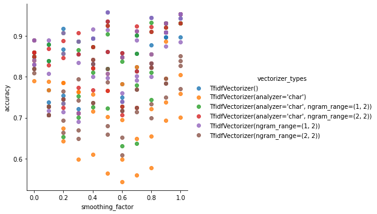

```python
sns.lmplot(x='smoothing_factor', y='accuracy', data=metrics_df, hue='vectorizer_types', fit_reg=False)
```

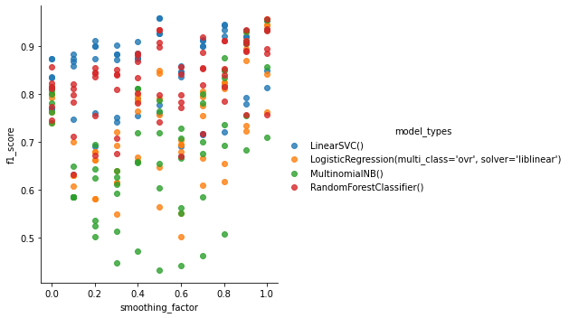

```python
sns.lmplot(x='smoothing_factor', y='f1_score', data=metrics_df, hue='model_types', fit_reg=False)
```

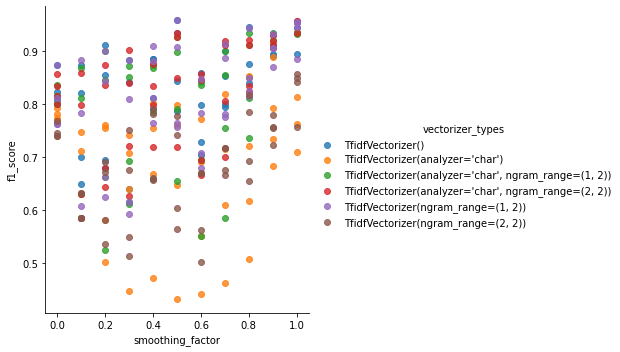

```python
sns.lmplot(x='smoothing_factor', y='f1_score', data=metrics_df, hue='vectorizer_types', fit_reg=False)
```

# Balancing Between Precision and Recall:

#### Precision is the ratio of correctly predicted positive observations to the total predicted positives.

- Formula: Precision = TP / (TP + FP)
- Interpretation: Precision answers the question, "Out of all instances predicted as positive, how many are actually positive?" It focuses on the accuracy of positive predictions.

#### Recall (Sensitivity or True Positive Rate) is the ratio of correctly predicted positive observations to the total actual positives.

- Formula: Recall = TP / (TP + FN)
- Interpretation: Recall answers the question, "Out of all actual positives, how many were correctly predicted?" It measures the model's ability to capture all positive instances.

#### The F1-score is the weighted mean of precision and recall. It provides a balance between precision and recall.

- Formula: F1-Score = 2 *(Precision* Recall) / (Precision + Recall)
- Interpretation: F1-Score considers both false positives and false negatives and provides a single score that balances precision and recall. It is especially useful when there is an imbalance between classes.

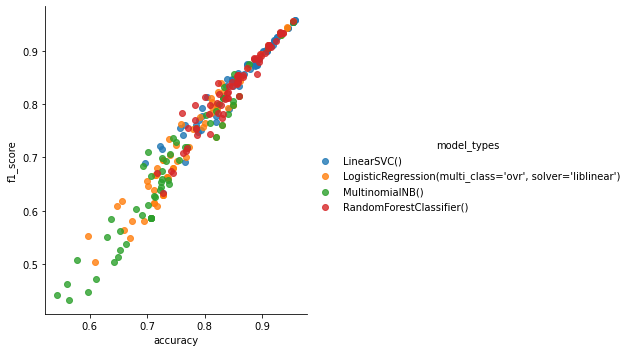

```python
sns.lmplot(x='accuracy', y='f1_score', data=metrics_df, hue='model_types', fit_reg=False)
```

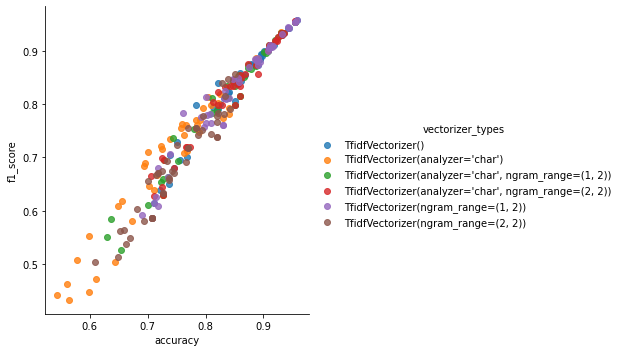

```python
sns.lmplot(x='accuracy', y='f1_score', data=metrics_df, hue='vectorizer_types', fit_reg=False)
```

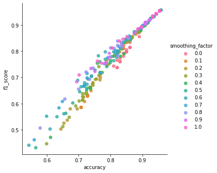

```python
sns.lmplot(x='accuracy', y='f1_score', data=metrics_df, hue='smoothing_factor', fit_reg=False)
```

# Model Types and Vector Types

#### It appears that the Support Vector Machine modeling method worked best, on average

```python
def heat_matrix(vals, rows, cols):
    heatmap_data = metrics_df.pivot_table(values=vals, index=rows,
                                      columns=cols, aggfunc='mean')

    # Create a heatmap using Seaborn
    plt.figure(figsize=(8, 6))
    sns.heatmap(heatmap_data, annot=True, cmap='PuBuGn', fmt=".2f", linewidths=.5)

    # Add labels and title
    plt.xlabel(cols)
    plt.ylabel(rows)
    plt.title(f'{vals} Heatmap')

    # Tilt x-axis tick labels
    plt.xticks(rotation=30, ha='right')


    # Display the plot
    plt.show()
```

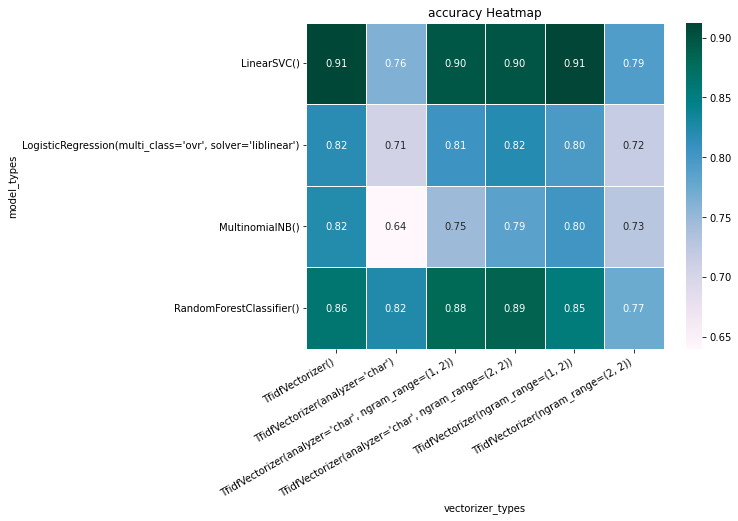

```python
heat_matrix(vals = 'accuracy', rows= 'model_types', cols= 'vectorizer_types')
```

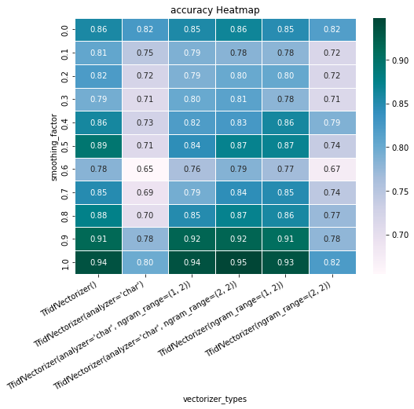

```python
heat_matrix(vals = 'accuracy', rows= 'smoothing_factor', cols= 'vectorizer_types')
```

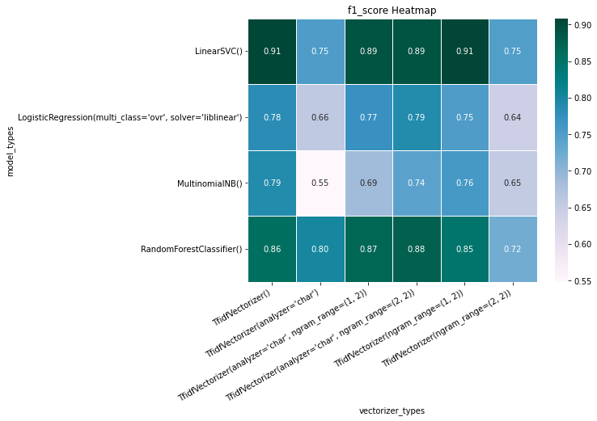

```python
heat_matrix(vals = 'f1_score', rows= 'model_types', cols= 'vectorizer_types')
```

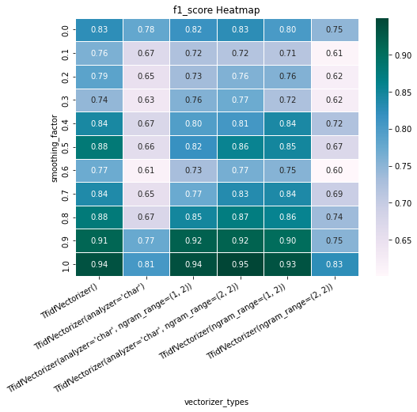

```python
heat_matrix(vals = 'f1_score', rows= 'smoothing_factor', cols= 'vectorizer_types')
```

# TESTING BLOCKS

```python
the_return['data_characteristics']
```

[output not shown]